# Biases in Predicting Recidivism: How COMPAS Failed and Alternate Models – Team 2

```r
summary(aov(predictions ~ race, test.is_violent_recid.qda))
```

```
##               Df Sum Sq Mean Sq F value Pr(>F)
## race           5  14.74  2.9485   41.66 <2e-16 ***
## Residuals   2981 211.00  0.0708
## ---
## Signif. codes:  0 '***' 0.001 '**' 0.01 '*' 0.05 '.' 0.1 ' ' 1
```

```r
kable(test.is_violent_recid.qda %>%
  group_by(race) %>%
  summarize_at(c("predictions"), mean), digits = 2)
```

| race | predictions |
| --- | --- |
| Caucasian | 1.04 |
| African-American | 1.12 |
| Asian | 1.00 |
| Hispanic | 1.03 |
| Native American | 2.00 |
| Other | 1.02 |

```r
summary(aov(predictions ~ race, test.is_violent_recid.qda[test.is_violent_recid.qda$race != "African-American",]))
```

```
##               Df Sum Sq Mean Sq F value Pr(>F)
## race           4  10.27  2.5669   74.24 <2e-16 ***
## Residuals   1474  50.96  0.0346
## ---
## Signif. codes:  0 '***' 0.001 '**' 0.01 '*' 0.05 '.' 0.1 ' ' 1
```

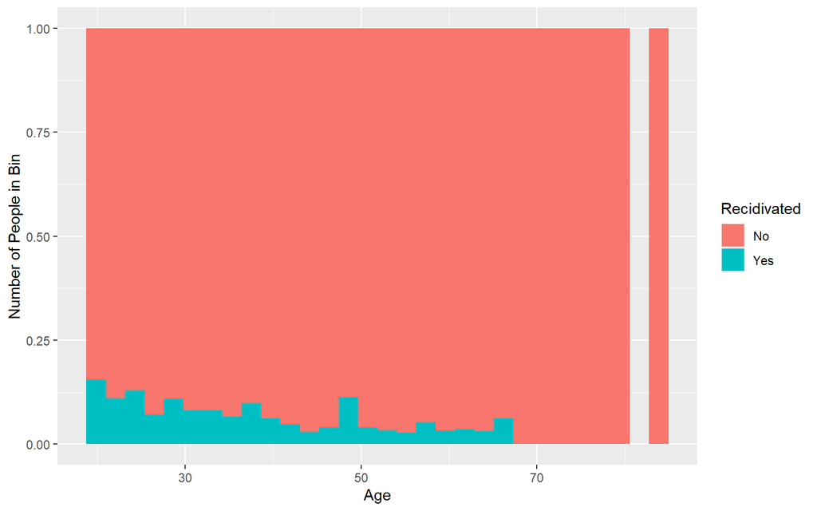

```r
#Age
ggplot(test.is_violent_recid.qda, aes(x = age, fill = as.factor(predictions))) +
  geom_histogram(position = 'fill') +
  scale_fill_discrete(name = "Recidivated", labels = c("No", "Yes")) +
  xlab('Age') +
  ylab('Number of People in Bin')
```

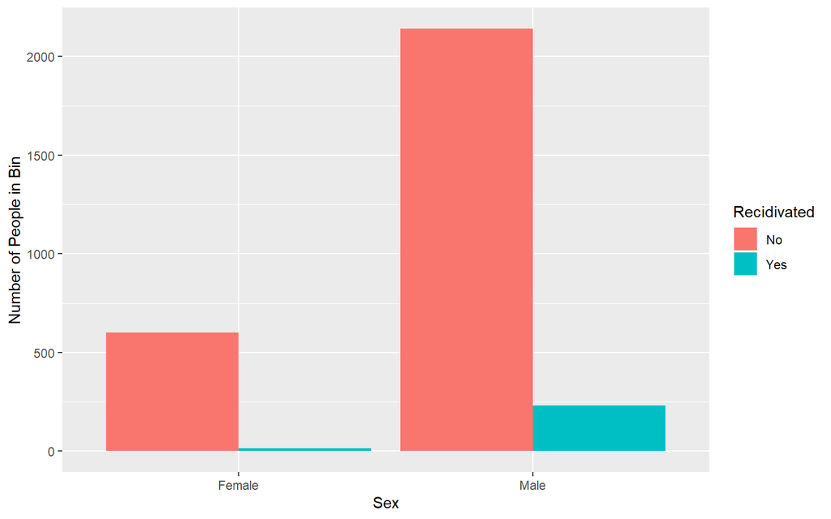

```r
#Sex
ggplot(test.is_violent_recid.qda, aes(x = sex, fill = as.factor(predictions))) +
  geom_bar(position = 'dodge') +
  scale_fill_discrete(name = "Recidivated", labels = c("No", "Yes")) +
  xlab('Sex') +
  ylab('Number of People in Bin')
```

```r
t.test(predictions ~ sex, data = test.is_violent_recid.qda)
```

```
##
##  Welch Two Sample t-test
##
## data:  predictions by sex
## t = -8.7563, df = 1981.8, p-value < 2.2e-16
## alternative hypothesis: true difference in means is not equal to 0
## 95 percent confidence interval:
##  -0.09185107 -0.05823599
## sample estimates:
## mean in group Female   mean in group Male
##             1.022764             1.097808
```

#### LDA QDA Model Summary:

is_recid: QDA has a lower misclassification rate than LDA; LDA has a larger AUC than QDA is_violent_recid: QDA has a lower misclassfication rate than LDA; LDA has a larger AUC than QDA We may only say that the LDA model for is_recid could be racist against African American.

#### Summary of Findings

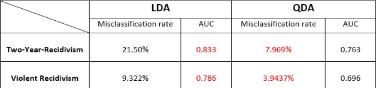

Back to top

## DANIEL – Random Forest and Neural Networks

Before I started, I removed all the columns that are information regarding that specific individual or the charge for both random forest model and neural network model. “C_charge_degree” variables with less than 10 in the data set were removed because we concluded that is not enough sample to train our model to be used for prediction. The outcome variables, “is_recid” and “is_violent_recid”, had to be converted to a factor for random forest model and to a boolean for neural network model. I separated the test dataset and training dataset by choosing the variables by random and 70% used for training and and 30% used for testing for both models. The Neural Network model needed extra cleaning because it only took quantitative inputs for every variable and they had to be scaled front [0,1]. All the factor variables were turned into dummy columns and all independent variables were normalized.

$X Normalized = \frac{(X-Xmin)}{(Xmax-Xmin)}$

We also had to change the name of the columns that included the “-” symbol because the neuralnet() function could take that symbol. Neural network models were repeated 4 or 5 times to find the best model with the lowest error rate and while keeping the number of repetition low to avoid overfitting the model to training dataset.

### Import CSV files

```r
rm(list= ls()[!(ls() %in% c('qda.pred.is_recid', "qda.pred.vis_recid",
                            "qda.test.data.r", "qda.test.data.v"))])

recid = read.csv("recid_data.csv", header = TRUE)
```

### Function to Analyze Confusion Matrix

```r
classMetrics <- function(score, y,
                         type = c("all", "accuracy", "sensitivity",
                                  "specificity", "ppv", "npv", "precision",
                                  "recall")) {
  # This command throws an error if the user specifies a "type" that
  # isn't supported by this function
  type <- match.arg(type, several.ok = TRUE)


  predicted = score
  observed = y
  #Confidence Matrix
  conf.matrix = table(predicted,observed)

  #Types
  A = conf.matrix[1,1]
  B = conf.matrix[1,2]
  C = conf.matrix[2,1]
  D = conf.matrix[2,2]

  acc = (A+D)/(A+B+C+D)
  spec = A/(A+C)
  sens = D/(B+D)
  ppv = D/(C+D)
  npv = A/(A+B)
  precision = ppv
  recall = sens
  m.error <- (B + C)/(A+B+C+D)

  nice = data.frame("accuracy"=acc, "sensitivity"=sens, "specificity"=spec, "ppv"=ppv, "npv"=npv, "precision"=precision,"recall"=recall,"misclassification rate"=m.error)
  if(type != "all"){
  nice = nice[type]
  nice = t(nice)
  colnames(nice) = c("value")
  }else{
  nice = t(nice)
  colnames(nice) = c("value")
  }

  list(conf.mat=conf.matrix,perf = nice)
}
```

### Exploratory Phase

#### Delete Irrelevant Columns

```r
# We don't need peoples' name do predict if that person will recid
recid$name=NULL
recid$first=NULL
recid$last=NULL

# We don't need age because we have age catagory
####recid$age=NULL
recid$age_cat=NULL

# Remove anything related to COMPAS
recid$compas_screening_date=NULL
recid$decile_score=NULL
recid$c_days_from_compas=NULL

# Case number/Identification number is an identification of the case, so won't be needed
recid$r_case_number=NULL
recid$vr_case_number=NULL
recid$X=NULL
recid$person_id=NULL

# Date of birth not needed becasue we have age category
recid$dob=NULL

# We don't need the what date the person was arrested because getting arrested in specific date has nothing to do with if the person will be recid or not. Also, we have to count of how many times the person was arrested.
recid$c_arrest_date=NULL
recid$c_offense_date=NULL
recid$r_offense_date=NULL
recid$r_jail_in=NULL
recid$r_jail_out=NULL
recid$vr_offense_date=NULL

# vr_charge or r_charge degree is not needed becasue this is a description of violent recidivism
recid$vr_charge_degree=NULL
recid$r_charge_degree=NULL

# Not Necessary
recid$r_days_from_arrest=NULL
recid$num_r_cases=NULL


# reorder the race variables and make Caucasian the baseline
recid$race = factor(recid$race, levels = c("Caucasian","African-American","Asian","Hispanic","Native American","Other"))
```

> Remove columns that describe the individual or the charge status

#### Delete Irrelevant Rows

```r
# Delete specific rows in c_charge_degree column
table(recid$c_charge_degree)
```

```
##
## (CO3)  (CT)  (F1)  (F2)  (F3)  (F5)  (F6)  (F7)  (M1)  (M2) (MO3) (NI0) (TCX)
##     1     1   152   821  5265     5     5    94  2680   734    67     6     1
##   (X)
##     1
```

```r
x1 = which(recid$c_charge_degree=="(CO3)")
recid = recid[-x1,]
x2 = which(recid$c_charge_degree=="(CT)")
recid = recid[-x2,]
x3 = which(recid$c_charge_degree=="(TCX)")
recid = recid[-x3,]
x4 = which(recid$c_charge_degree=="(X)")
recid = recid[-x4,]
x5 = which(recid$c_charge_degree=="(F5)")
recid = recid[-x5,]
x6 = which(recid$c_charge_degree=="(F6)")
recid = recid[-x6,]
x7 = which(recid$c_charge_degree=="(NI0)")
recid = recid[-x7,]
table(recid$c_charge_degree)
```

```
##
## (CO3)  (CT)  (F1)  (F2)  (F3)  (F5)  (F6)  (F7)  (M1)  (M2) (MO3) (NI0) (TCX)
##     0     0   152   821  5265     0     0    94  2680   734    67     0     0
##   (X)
##     0
```

> The factors with quantities of single digit will not be effective when predicting if the specific factor makes a significant impact on `is_recid`

### Random Forest

```r
# Change outcome variables to a factor
recid$is_recid[recid$is_recid==1] = "yes"
recid$is_recid[recid$is_recid==0] = "no"

recid$is_violent_recid[recid$is_violent_recid==1] = "yes"
recid$is_violent_recid[recid$is_violent_recid==0] = "no"
```

> Change the outcome variables to be a factor

```r
set.seed(222)
ind = sample(2,nrow(recid),replace=TRUE,prob=c(0.7,0.3))
recid.train = recid[ind==1,]
recid.test = recid[ind==2,]
```

> Divide the `recid` dataset into two data sets, train and test. The training dataset is made up of 70% randomcly chosen from the `recid` dataset. The rest of the 30% will be assigned as a test dataset

#### Use the `randomForest` command to fit a random forest to `recid.train` of `is_recid`

```r
recid.rf.1 = randomForest(as.factor(is_recid) ~.-is_violent_recid, data = recid.train,mytr=sqrt(12),importance=TRUE)
recid.rf.1
```

```
##
## Call:
##  randomForest(formula = as.factor(is_recid) ~ . - is_violent_recid,      data = recid.train, mytr = sqrt(12), importance = TRUE)
##                Type of random forest: classification
##                      Number of trees: 500
## No. of variables tried at each split: 3
##
##         OOB estimate of  error rate: 20.39%
## Confusion matrix:
##       no  yes class.error
## no  3943  650   0.1415197
## yes  758 1553   0.3279965
```

> Perform `randomForest` on the `is_recid` and convert the outcome into a factor

#### Use the `randomForest` command to fit a random forest to `recid.train` of `is_violent_recid`

```r
recid.rf.2 = randomForest(as.factor(is_violent_recid) ~.-is_recid, data = recid.train,mytr=sqrt(12),importance=TRUE)
recid.rf.2
```

```
##
## Call:
##  randomForest(formula = as.factor(is_violent_recid) ~ . - is_recid,      data = recid.train, mytr = sqrt(12), importance = TRUE)
##                Type of random forest: classification
##                      Number of trees: 500
## No. of variables tried at each split: 3
##
##         OOB estimate of  error rate: 7.94%
## Confusion matrix:
##       no yes class.error
## no  6347  17 0.002671276
## yes  531   9 0.983333333
```

> Perform `randomForest` on the `is_violent_recid` and convert the outcome into a factor

#### Finding Standard Classification Error of `Random Forest` model on the Training data of `is_recid`

```r
rf.misclass.1 = 1-(recid.rf.1$confusion[1,1]+recid.rf.1$confusion[2,2])/(recid.rf.1$confusion[1,1]+recid.rf.1$confusion[2,2]+recid.rf.1$confusion[1,2]+recid.rf.1$confusion[2,1])
rf.misclass.1
```

```
## [1] 0.2039397
```

> The misclassification rate of Random Forest model on `is_recid` is 20.4%

#### Finding Standard Classification Error of `Random Forest` model on the Training data of `is_violent_recid`

```r
rf.misclass.2 = 1-(recid.rf.2$confusion[1,1]+recid.rf.2$confusion[2,2])/(recid.rf.2$confusion[1,1]+recid.rf.2$confusion[2,2]+recid.rf.2$confusion[1,2]+recid.rf.2$confusion[2,1])
rf.misclass.2
```

```
## [1] 0.07937428
```

> The misclassification rate of Random Forest model on `is_violent_recid` is 7.94%

#### Construct a variable importance plot of `is_recid`

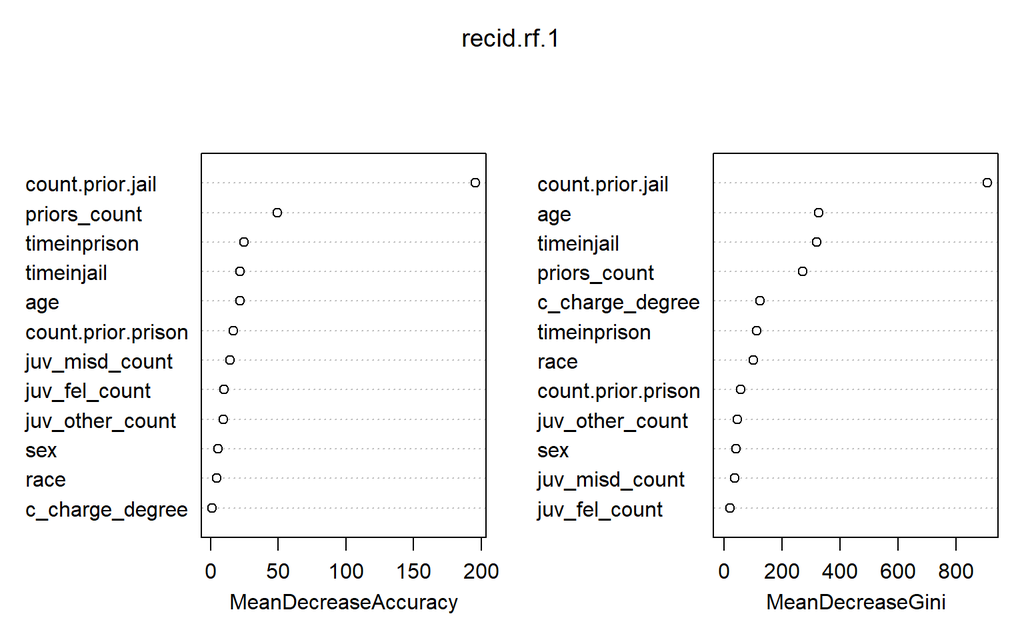

```r
varImpPlot(recid.rf.1)
```

> `count.prior.jail` variable is the most important variable in the `is_recid` training dataset

#### Construct a variable importance plot of `is_volent_recid`

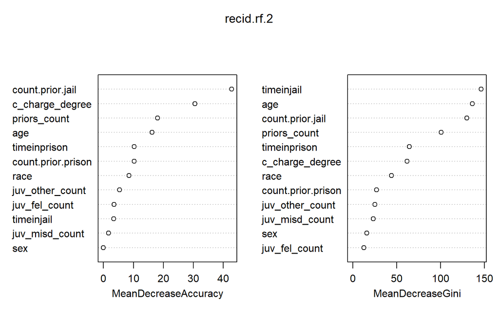

```r
varImpPlot(recid.rf.2)
```

> `count.prior.jail` and `c_change_degree` variables are the most important variable in the `is_violent_recid` training dataset

#### Use the `predict` command to obtain probability estimates on the test data `is_recid`

```r
predict.rf.1 = predict(recid.rf.1,newdata=recid.test,type="class")
predict.rf.prob.1 = predict(recid.rf.1,newdata=recid.test,type="prob")

#------
classMetrics(predict.rf.1,recid.test$is_recid, type = "all")
```

```
## $conf.mat
##          observed
## predicted   no  yes
##       no  1689  299
##       yes  295  626
##
## $perf
##                            value
## accuracy               0.7958061
## sensitivity            0.6767568
## specificity            0.8513105
## ppv                    0.6796960
## npv                    0.8495976
## precision              0.6796960
## recall                 0.6767568
## misclassification.rate 0.2041939
```

> Accuracy of Random Forest model applied to test dataset of `is_recid` is 79.5% and the misclassification rate is 20.5%

#### Use the `predict` command to obtain probability estimates on the test data `is_violent_recid`

```r
predict.rf.2 = predict(recid.rf.2,newdata=recid.test,type="class")
predict.rf.prob.2 = predict(recid.rf.2,newdata=recid.test,type="prob")

#------
classMetrics(predict.rf.2,recid.test$is_violent_recid, type = "all")
```

```
## $conf.mat
##          observed
## predicted   no  yes
##       no  2685  215
##       yes    6    3
##
## $perf
##                             value
## accuracy               0.92402888
## sensitivity            0.01376147
## specificity            0.99777035
## ppv                    0.33333333
## npv                    0.92586207
## precision              0.33333333
## recall                 0.01376147
## misclassification.rate 0.07597112
```

#### The ROC curve for the pruned tree of `is_recid`

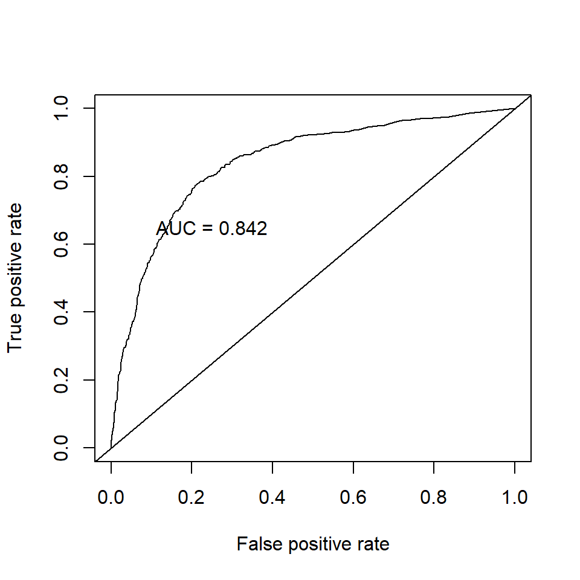

```r
#roc.rf.1 = roc(recid.test$is_recid,predict.rf.prob.1[,2])
#plot(roc.rf.1,col="steelblue")


# Evaluate the model
pred <- prediction(predict.rf.prob.1[,2], recid.test$is_recid)
roc.perf = performance(pred, measure = "tpr", x.measure = "fpr")
auc.train <- performance(pred, measure = "auc")
auc.train <- auc.train@y.values

# Plot
plot(roc.perf)
abline(a=0, b= 1)
text(x = .25, y = .65 ,paste("AUC = ", round(auc.train[[1]],3), sep = ""))
```

> AUC of Random Forest model on `is_recid` is 0.842

#### The ROC curve for the pruned tree of `is_violent_recid`

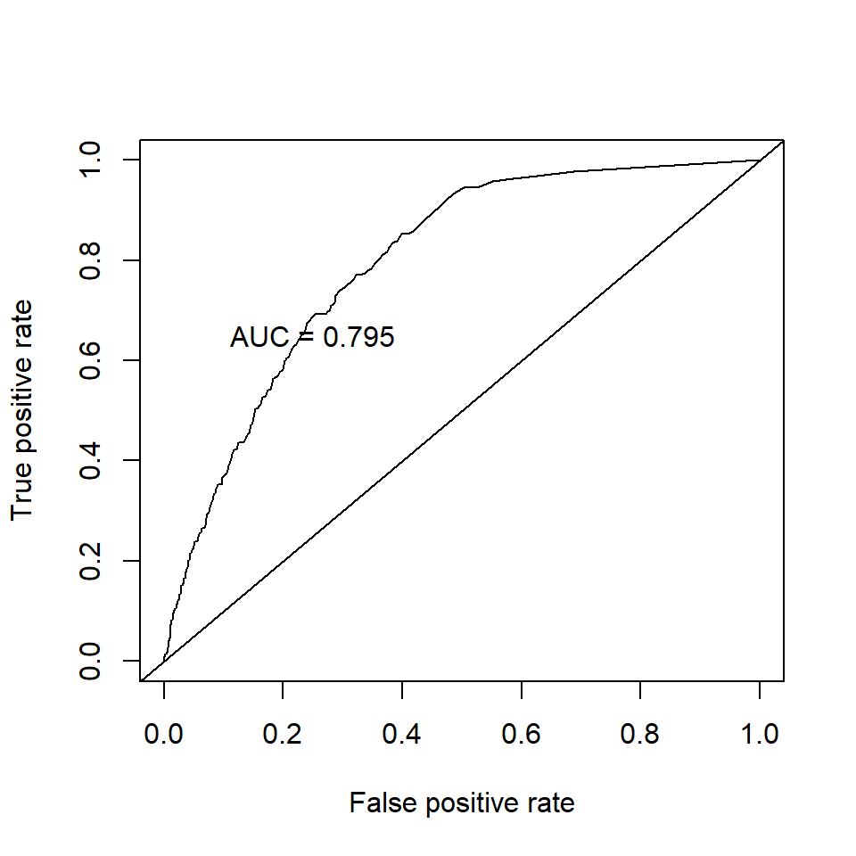

```r
#roc.rf.2 = roc(recid.test$is_violent_recid,predict.rf.prob.2[,2])
#plot(roc.rf.2,col="green")

# Evaluate the model
pred <- prediction(predict.rf.prob.2[,2], recid.test$is_violent_recid)
roc.perf = performance(pred, measure = "tpr", x.measure = "fpr")
auc.train <- performance(pred, measure = "auc")
auc.train <- auc.train@y.values

# Plot
plot(roc.perf)
abline(a=0, b= 1)
text(x = .25, y = .65 ,paste("AUC = ", round(auc.train[[1]],3), sep = ""))
```

### Artificial Neural Network

#### Add New Dictionary

```r
library(dplyr)
library(neuralnet)
library(GGally)
rm(list= ls()[!(ls() %in% c('qda.pred.is_recid', "qda.pred.vis_recid",
                            "qda.test.data.r", "qda.test.data.v"))])

recid = read.csv("recid_data.csv", header = TRUE)
```

#### Delete Irrelevant Columns

```r
# We don't need peoples' name do predict if that person will recid
recid$name=NULL
recid$first=NULL
recid$last=NULL

# We don't need age because we have age catagory
####recid$age=NULL
recid$age_cat=NULL

# Remove anything related to COMPAS
recid$compas_screening_date=NULL
recid$decile_score=NULL
recid$c_days_from_compas=NULL

# Case number/Identification number is an identification of the case, so won't be needed
recid$r_case_number=NULL
recid$vr_case_number=NULL
recid$X=NULL
recid$person_id=NULL

# Date of birth not needed becasue we have age category
recid$dob=NULL

# We don't need the what date the person was arrested because getting arrested in specific date has nothing to do with if the person will be recid or not. Also, we have to count of how many times the person was arrested.
recid$c_arrest_date=NULL
recid$c_offense_date=NULL
recid$r_offense_date=NULL
recid$r_jail_in=NULL
recid$r_jail_out=NULL
recid$vr_offense_date=NULL

# vr_charge or r_charge degree is not needed becasue this is a description of violent recidivism
recid$vr_charge_degree=NULL
recid$r_charge_degree=NULL

# Not Necessary
recid$r_days_from_arrest=NULL
recid$num_r_cases=NULL


# reorder the race variables and make Caucasian the baseline
recid$race = factor(recid$race, levels = c("Caucasian","African-American","Asian","Hispanic","Native American","Other"))
```

#### Delete Irrelevant Rows

```r
# Delete specific rows in c_charge_degree column
table(recid$c_charge_degree)
```

```
##
## (CO3)  (CT)  (F1)  (F2)  (F3)  (F5)  (F6)  (F7)  (M1)  (M2) (MO3) (NI0) (TCX)
##     1     1   152   821  5265     5     5    94  2680   734    67     6     1
##   (X)
##     1
```

```r
x1 = which(recid$c_charge_degree=="(CO3)")
recid = recid[-x1,]
x2 = which(recid$c_charge_degree=="(CT)")
recid = recid[-x2,]
x3 = which(recid$c_charge_degree=="(TCX)")
recid = recid[-x3,]
x4 = which(recid$c_charge_degree=="(X)")
recid = recid[-x4,]
x5 = which(recid$c_charge_degree=="(F5)")
recid = recid[-x5,]
x6 = which(recid$c_charge_degree=="(F6)")
recid = recid[-x6,]
x7 = which(recid$c_charge_degree=="(NI0)")
recid = recid[-x7,]
table(recid$c_charge_degree)
```

```
##
## (CO3)  (CT)  (F1)  (F2)  (F3)  (F5)  (F6)  (F7)  (M1)  (M2) (MO3) (NI0) (TCX)
##     0     0   152   821  5265     0     0    94  2680   734    67     0     0
##   (X)
##     0
```

#### Create a New Tab for is_recid outcome in Boolean to operate “Neural Network” Package

```r
# Change the Outcome Variables to Boolean to operate ANN
recid.new = recid %>% mutate(is_recid = ifelse(is_recid=="yes",TRUE,FALSE),is_violent_recid = ifelse(is_violent_recid=="yes",TRUE,FALSE))



# Change Categorical Variables to Dummy Variables
recid.new = fastDummies::dummy_cols(recid.new)

# Change Numberical variables to fit from [0,1]
scale01 <- function(x){
  (x - min(x)) / (max(x) - min(x))
}
recid.new = recid.new %>% mutate(juv_fel_count=scale01(juv_fel_count), juv_misd_count=scale01(juv_misd_count),juv_other_count=scale01(juv_other_count),priors_count=scale01(priors_count),count.prior.jail=scale01(count.prior.jail),count.prior.prison=scale01(count.prior.prison),age=scale01(age))

# Remove Redundant Columns
recid.new$sex=NULL
recid.new$race=NULL
recid.new$timeinjail=NULL
recid.new$timeinprison=NULL
recid.new$is.recid=NULL
recid.new$c_charge_degree=NULL


# Change Names of Columns
names(recid.new)[8] = "count_prior_jail"
names(recid.new)[9] = "count_prior_prison"
names(recid.new)[13] = "race_african_american"
names(recid.new)[16] = "race_native_american"
names(recid.new)[21] = "f2"
names(recid.new)[20] = "f1"
names(recid.new)[22] = "f3"
names(recid.new)[25] = "f7"
names(recid.new)[26] = "m1"
names(recid.new)[27] = "m2"
names(recid.new)[28] = "mo3"

# Remove extra unnecessary columns
names(recid.new)[18] = "co3"
names(recid.new)[19] = "ct"
names(recid.new)[23] = "f5"
names(recid.new)[24] = "f6"
names(recid.new)[29] = "ni0"
names(recid.new)[30] = "tcx"
names(recid.new)[31] = "x"

recid.new$co3 =NULL
recid.new$ct=NULL
recid.new$f5=NULL
recid.new$f6=NULL
recid.new$ni0=NULL
recid.new$tcx=NULL
recid.new$x=NULL
```

> Neural Networks only deal with quantitative variables so I had to clean up the data. All the factor variables were created as dummny variables, then the original factor variables were deleted. The independent variables were normailzed so that they are scaled in an equal manner

#### Create Train and Test data set

```r
set.seed(222)
ind = sample(2,nrow(recid.new),replace=TRUE,prob=c(0.7,0.3))
recid.training = recid.new[ind==1,]
recid.testing = recid.new[ind==2,]

recid.test.1 = recid[ind==2,]
```

```r
set.seed(333)
recid.ann.1 = neuralnet(is_recid ~ age + juv_fel_count + juv_misd_count + juv_other_count + priors_count + count_prior_jail + count_prior_prison + sex_Female + sex_Male + race_african_american + race_Asian + race_Caucasian    + race_Hispanic + race_native_american + race_Other + f1 + f2 + f3 + f7 + m1 + m2 + mo3, data=recid.training, linear.output=FALSE, err.fct='ce', likelihood=TRUE,hidden=1,lifesign="full",rep=5)
```

```
## hidden: 1    thresh: 0.01    rep: 1/5    steps:      67  error: 0.00956  aic: 50.01912   bic: 221.01552  time: 0.09 secs
## hidden: 1    thresh: 0.01    rep: 2/5    steps:      87  error: 0.00826  aic: 50.01652   bic: 221.01292  time: 0.1 secs
## hidden: 1    thresh: 0.01    rep: 3/5    steps:      66  error: 0.00946  aic: 50.01892   bic: 221.01532  time: 0.08 secs
## hidden: 1    thresh: 0.01    rep: 4/5    steps:      70  error: 0.01     aic: 50.02      bic: 221.0164   time: 0.09 secs
## hidden: 1    thresh: 0.01    rep: 5/5    steps:      73  error: 0.00941  aic: 50.01882   bic: 221.01523  time: 0.08 secs
```

```r
set.seed(333)
recid.ann.2 = neuralnet(is_violent_recid ~ age + juv_fel_count + juv_misd_count + juv_other_count + priors_count + count_prior_jail + count_prior_prison + sex_Female + sex_Male + race_african_american + race_Asian + race_Caucasian    + race_Hispanic + race_native_american + race_Other + f1 + f2 + f3 + f7 + m1 + m2 + mo3, data=recid.training, linear.output=FALSE, err.fct='ce', likelihood=TRUE,hidden=1,lifesign="full",rep=4)
```

```
## hidden: 1    thresh: 0.01    rep: 1/4    steps:      67  error: 0.00956  aic: 50.01912   bic: 221.01552  time: 0.08 secs
## hidden: 1    thresh: 0.01    rep: 2/4    steps:      87  error: 0.00826  aic: 50.01652   bic: 221.01292  time: 0.11 secs
## hidden: 1    thresh: 0.01    rep: 3/4    steps:      66  error: 0.00946  aic: 50.01892   bic: 221.01532  time: 0.08 secs
## hidden: 1    thresh: 0.01    rep: 4/4    steps:      70  error: 0.01     aic: 50.02      bic: 221.0164   time: 0.09 secs
```

> Neural Network model was applied to `is_violent_recid` training dataset. The second repetition had the lowest error rate

#### Plot the Neural Network of `is_recid`

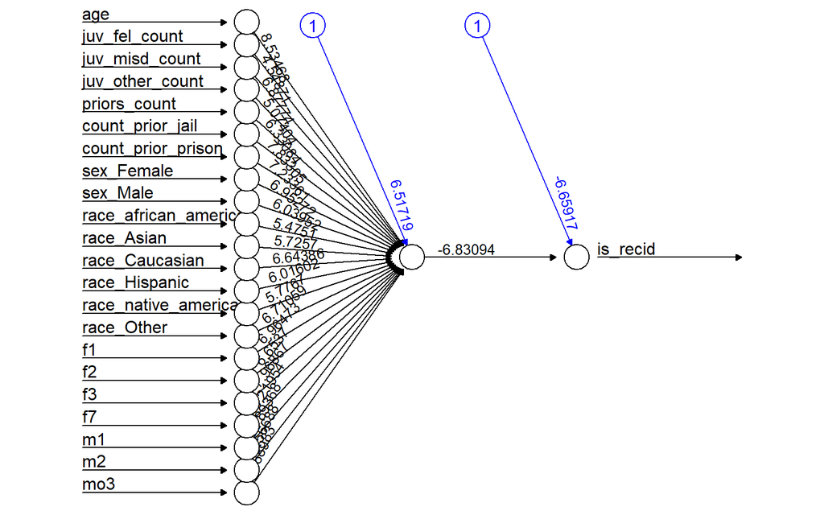

```r
plot(recid.ann.1, rep = 1)
```

> The Neural Network model on `is_recid`, African-American has weight of 5.48 and Caucasian has weight of 6.64. The model is not racially bias towards African-American

#### Plot the Neural Network of `is_violent_recid`

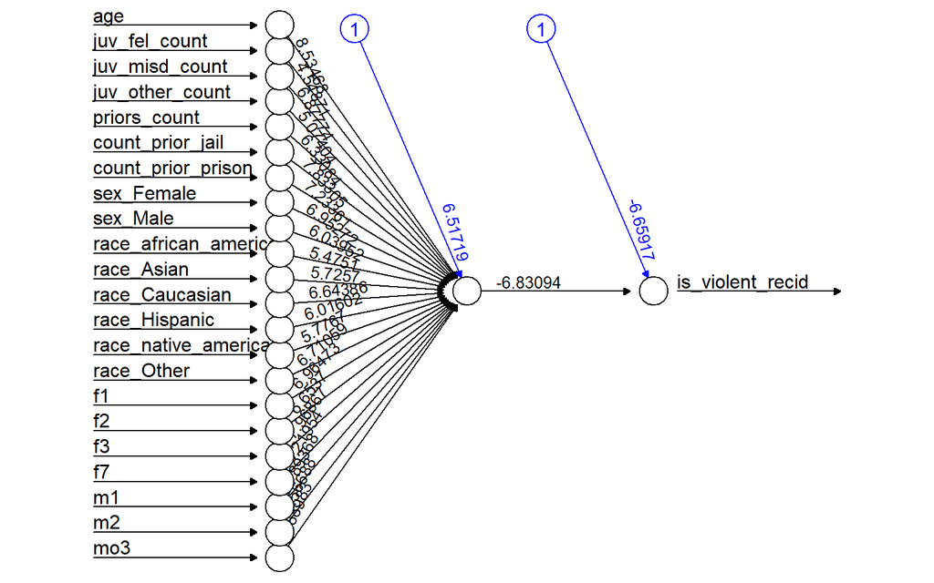

```r
plot(recid.ann.2, rep = 1)
```

#### Confusion Matrix and Misclassification Rate on Training & Testing Data on NN2

```r
# Remove the output variable before using the function "compute"
ann.test.out.1 = neuralnet::compute(recid.ann.1,recid.testing[,c(-6,-7)],rep=1)

# Create a Confusion Matrix to find Misclassification Rate
ann.test.out.result.1 = ann.test.out.1$net.result
ann.test.pred.1 = ifelse(ann.test.out.result.1>0.5,1,0)
ann.test.tab.1 = table(recid.test.1$is_recid,ann.test.pred.1)
ann.test.tab.1
```

```
##    ann.test.pred.1
##        0
##   0 1984
##   1  925
```

```r
#------
#classMetrics(ann.test.pred.1,recid.test.1$is_recid, type = "all")

mis.1 = 1-sum(diag(ann.test.tab.1))/sum(ann.test.tab.1)
mis.1
```

```
## [1] 0.3179787
```

> The Neural Network model on `is_recid` has misclassification rate of 31.8%

```r
# Remove the output variable before using the function "compute"
ann.test.out.2 = neuralnet::compute(recid.ann.2,recid.testing[,c(-6,-7)],rep=1)

# Create a Confusion Matrix to find Misclassification Rate
ann.test.out.result.2 = ann.test.out.2$net.result
ann.test.pred.2 = ifelse(ann.test.out.result.2>0.5,1,0)
ann.test.tab.2 = table(recid.test.1$is_violent_recid,ann.test.pred.2)
ann.test.tab.2
```

```
##    ann.test.pred.2
##        0
##   0 2691
##   1  218
```

```r
#------
#classMetrics(ann.test.pred.2,recid.test.1$is_violent_recid, type = "all")

mis.2 = 1-sum(diag(ann.test.tab.2))/sum(ann.test.tab.2)
mis.2
```

```
## [1] 0.07493984
```

> The Neural Network model on `is_violent_recid` has misclassification rate of 7.49%

#### Bar Plot of`is_recid`

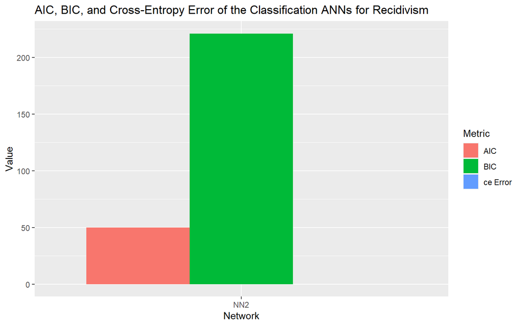

```r
# Bar plot of results
class.ann = tibble('Network' = rep(c("NN2"), each = 3),
                       'Metric' = rep(c('AIC', 'BIC', 'ce Error'), length.out = 3),
                       'Value' = c(recid.ann.1$result.matrix[4,1],
                                   recid.ann.1$result.matrix[5,1], recid.ann.1$result.matrix[1,1]))

class.ann %>%
  ggplot(aes(Network, Value, fill = Metric)) +
  geom_col(position = 'dodge')  +
  ggtitle("AIC, BIC, and Cross-Entropy Error of the Classification ANNs for Recidivism")
```

#### Bar Plot of`is_violent_recid`

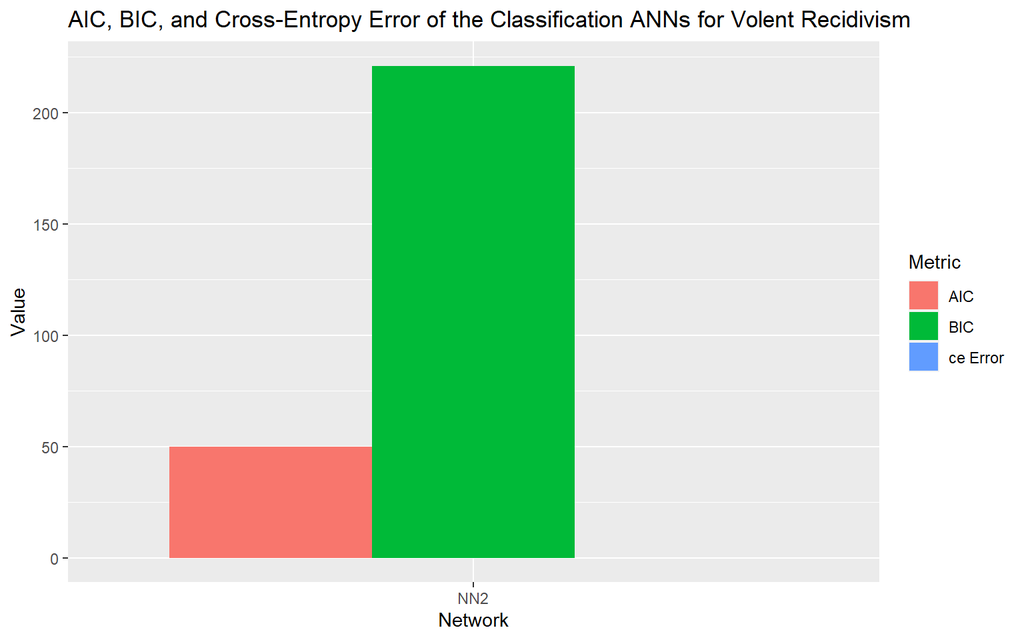

```r
# Bar plot of results
class.ann = tibble('Network' = rep(c("NN2"), each = 3),
                       'Metric' = rep(c('AIC', 'BIC', 'ce Error'), length.out = 3),
                       'Value' = c(recid.ann.2$result.matrix[4,1],
                                   recid.ann.2$result.matrix[5,1], recid.ann.2$result.matrix[1,1]))

class.ann %>%
  ggplot(aes(Network, Value, fill = Metric)) +
  geom_col(position = 'dodge')  +
  ggtitle("AIC, BIC, and Cross-Entropy Error of the Classification ANNs for Volent Recidivism")
```

### Random Forest model & Neural Network Findings & Summary

**Was the Model Biased?**

Unfortunately, it is difficult to measure if the model is biased with the Random Forest model because the measure of importance of each variable can be measured but which specific race will result in higher “is_recid” can’t be found. However, I can estimate the race bias in the model by predicting the model on the test dataset when it is divided by African-American and Caucasian subgroups. The FPR of Caucasian individuals is ~10% lower than the FPR of African-American individuals. This result suggests the model predicted a African-American group as will recidivate in the future but had a higher proportion of the predicted individual was false. From this analysis, my Random Forest model for “is_recid” is racially biased.

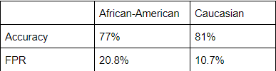

Neural network models are less biased because the weight on African-American individuals is 5.48; in contrast, the weight on Caucasian individuals is 6.64.

**Was the Model Biased?**

Unfortunately, it is difficult to measure if the model is biased with the Random Forest model because the measure of importance of each variable can be measured but which specific race will result in higher “is_violent_recid” can’t be found. However, I can estimate the race bias in the model by predicting the model on the test dataset when it is divided by African-American and Caucasian subgroups. The FPR of Caucasian individuals is ~0.022% lower than the FPR of African-American individuals. This result suggests my Random Forest model for “is_violent_recid” is racially unbiased.

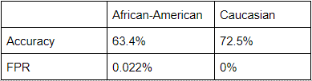

Neural network models are less biased because the weight on African-American individuals is 5.48; in contrast, the weight on Caucasian individuals is 6.64.

**In Summary**

- Random Forest model performs better than Neural Network model with lower misclassification rate (0.21 vs. 0.32) [`is_recid]
- Random Forest model performs similar compared to Neural Network model with misclassification rate (0.076 vs. 0.075) [`is_violent_recid]
- By comparing the two models, I can conclude that the Random Forest model performs better than the Neural Network model

Back to top

## JOSE – Linear Regression & K-Nearest-Neighbors Classifier

My part of the analysis consists of taking the recidivism data set and applying simple linear regression and k-nearest neighbor as classification methods. The analysis is applied by breaking down the data set into violent and non-violent recidivism. Before applying these methods, however, I use k-means methods to the data to discern whether there are any discernible clusters of observations within the data set.

### Data Selection

```r
rm(list= ls()[!(ls() %in% c('qda.pred.is_recid', "qda.pred.vis_recid",
                            "qda.test.data.r", "qda.test.data.v"))])

recid <- read.csv(file = 'recid_data.csv', row.names = 1)
recid <- recid[which(recid$decile_score >= 0),]

# We don't need peoples' name do predict if that person will recid
recid$name=NULL
recid$first=NULL
recid$last=NULL

# We don't need age because we have age catagory
####recid$age=NULL
recid$age_cat=NULL

# Remove anything related to COMPAS
recid$compas_screening_date=NULL
recid$decile_score=NULL
recid$c_days_from_compas=NULL

# Case number/Identification number is an identification of the case, so won't be needed
recid$r_case_number=NULL
recid$vr_case_number=NULL
recid$X=NULL
recid$person_id=NULL

# Date of birth not needed becasue we have age category
recid$dob=NULL

# We don't need the what date the person was arrested because getting arrested in specific date has nothing to do with if the person will be recid or not. Also, we have to count of how many times the person was arrested.
recid$c_arrest_date=NULL
recid$c_offense_date=NULL
recid$r_offense_date=NULL
recid$r_jail_in=NULL
recid$r_jail_out=NULL
recid$vr_offense_date=NULL

# vr_charge or r_charge degree is not needed becasue this is a description of violent recidivism
recid$vr_charge_degree=NULL
recid$r_charge_degree=NULL

# FOR NOW
#recid$c_charge_degree=NULL
recid$r_days_from_arrest=NULL

# Change na to 0
#recid$num_r_cases[is.na(recid$num_r_cases)]=0

recid$num_r_cases=NULL

names(recid)
```

```
##  [1] "sex"                "race"               "age"
##  [4] "juv_fel_count"      "juv_misd_count"     "juv_other_count"
##  [7] "priors_count"       "c_charge_degree"    "is_recid"
## [10] "is_violent_recid"   "count.prior.jail"   "count.prior.prison"
## [13] "timeinjail"         "timeinprison"
```

```r
avgage.nvrecid <- recid %>% group_by(is_recid) %>% summarise(mean(age))
avgage.vrecid <- recid %>% group_by(is_violent_recid) %>% summarise(mean(age))
```

### Divide data intro training and test sets before modeling

```r
## extract training and test data sets
train <- sample(1:nrow(recid), round(nrow(recid)/2, 0))
test <- recid[-train,]
#dim(test)
#length(train)
```